# Forecasting The UK Inflation Rate 1965/Q1-2019/Q3

Vitalii Rudko

November, 2020

# 1 Preparing Data

This section is completely technical, so it may be omitted.

```r
#Loading packages.
library(xts)
library(zoo)
library(dplyr)
library(arfima)
library(ggplot2)
library(LongMemoryTS)
library(forecast)
library(MTS)
library(roll)
library(fDMA)
library(tseries)
library(gridExtra)
library(arfima)
library(rugarch)
```

```r
#Importing data.
data <- read.csv("D:/R_dir/AMM/UKrpiq.csv")
```

```r
#Extracting data.
data <- data.frame(cbind(data$X, data$InflatQ))
names(data) <- c("Date", "InfQ")

#Formatting the Date column.
data$Date <- as.yearqtr(data$Date)

#Removing missing values.
data <- data %>% filter(InfQ != "#N/A")

#Formatting the InfQ column.
data$InfQ <- as.numeric(data$InfQ)

#Saving the last 4 observations.
last4 <- data %>% filter(Date > 2019.5)

#Narrowing the time window to 1965(1)-2019(3).
data <- data %>% filter(Date >= 1965 & Date <= 2019.5)
```

```r
#Creating time series.
inf.xts <- na.omit(xts(data$InfQ, order.by = data$Date))
inf.ts <- na.omit(ts(data$InfQ, start = c(1965,1), frequency = 4))
```

# 2 Preliminary Analysis

At the first look, we guess that the series is non-stationary.

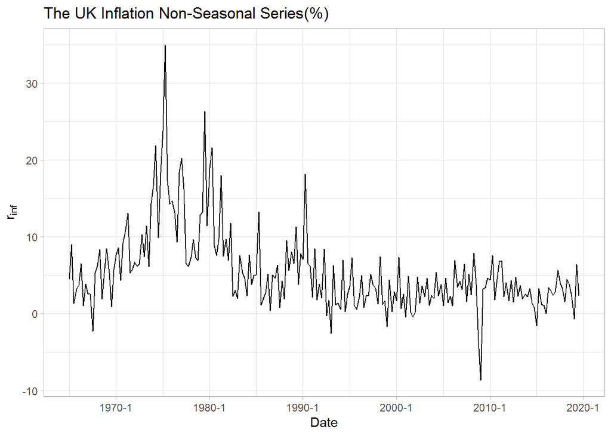

```r
#Plotting actual series of InfQ variable.
ggplot(data)+
  geom_line(aes(x = Date, y = InfQ))+
  labs(title = "The UK Inflation Non-Seasonal Series(%)",
       y = expression('r'[inf]))+
  theme_light()
```

The ACF plot below shows a seasonal pattern of the order 4, thus seasonal differencing of that order must be considered.

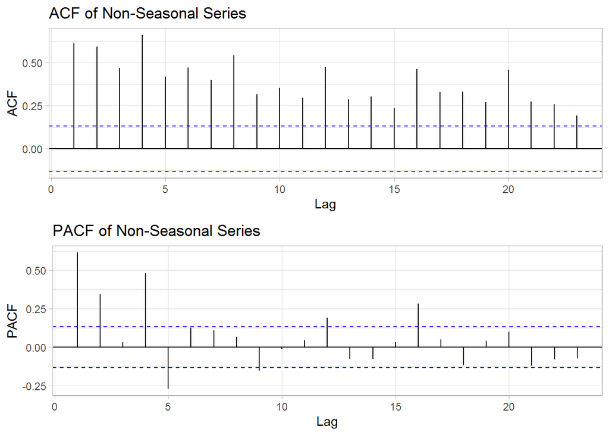

```r
#Plotting Acf and Pacf of non-seasonal series.
plot1 <- ggAcf(inf.xts)+
          theme_light()+
          labs(title = "ACF of Non-Seasonal Series")
plot2 <- ggPacf(inf.xts)+
          theme_light()+
          labs(title = "PACF of Non-Seasonal Series")

grid.arrange(plot1,
             plot2,
             nrow = 2)
```

ADF test accepts H0 – the process is non-stationary.

```r
#Testing stationarity of InfQ variable.
#H0: non-stationary;
#H1: stationary;
adf.test(inf.xts)
```

```
##
##  Augmented Dickey-Fuller Test
##
## data:  inf.xts
## Dickey-Fuller = -3.1008, Lag order = 6, p-value = 0.1141
## alternative hypothesis: stationary
```

Ljung-Box test shows the presence of autocorrelation, which well seen in the ACF plot.

```r
#Ljung-Box for detecting autocorrelations in non-seasonal series.
#H0: all correlations are zero;
#H1: there exists at least one, which is significantly higher than zero;
Box.test(inf.ts, lag = 30, type = "Ljung-Box")
```

```
##
##  Box-Ljung test
##
## data:  inf.ts
## X-squared = 971.28, df = 30, p-value < 2.2e-16
```

As we can see the data has non-normal distribution.

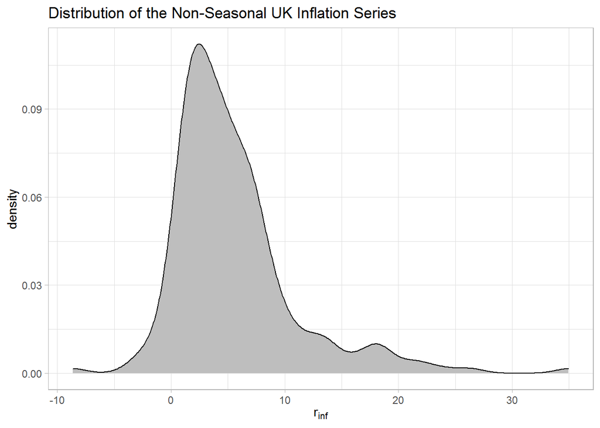

```r
#Plotting the distribution of non-seasonal series.
ggplot(data)+
      geom_density(aes(InfQ), fill = "Grey")+
      labs(title = "Distribution of the Non-Seasonal UK Inflation Series",
           x = expression('r'[inf]))+
  theme_light()
```

The Shapiro-Wilk test confirms it.

```r
#Testing normality of the distribution of seasonal series with Shapiro-Wilk test.
#H0: data normaly distributed;
#H1: data is not normaly distributied;
shapiro.test(inf.ts)
```

```
##
##  Shapiro-Wilk normality test
##
## data:  inf.ts
## W = 0.85386, p-value = 1.369e-13
```

ARCH tests reject a H0 in every case. Hovewer, it must be additionaly checked in seasonal series.

```r
#Testing ARCH effect in non-seasonal series.
#H0: there is no ARCH effect;
#H1: there is ARCH effect with a specified lag;
archtest(as.vector(inf.ts), lag = 2)
```

```
##
##  Engle's LM ARCH Test
##
## data:  as.vector(inf.ts)
## statistic = 37.937, lag = 2, p-value = 5.783e-09
## alternative hypothesis: ARCH effects of order 2 are present
```

```r
archtest(as.vector(inf.ts), lag = 5)
```

```
##
##  Engle's LM ARCH Test
##
## data:  as.vector(inf.ts)
## statistic = 45.152, lag = 5, p-value = 1.351e-08
## alternative hypothesis: ARCH effects of order 5 are present
```

```r
archtest(as.vector(inf.ts), lag = 10)
```

```
##
##  Engle's LM ARCH Test
##
## data:  as.vector(inf.ts)
## statistic = 46.649, lag = 10, p-value = 1.094e-06
## alternative hypothesis: ARCH effects of order 10 are present
```

```r
#Calculating seasonal series.
data$InfQ_diff4 <- c(rep(NA, 4), diff(data$InfQ, lag = 4))
inf4.xts  <- na.omit(xts(data$InfQ_diff4, order.by = data$Date))
inf4.ts  <- na.omit(ts(data$InfQ_diff4, start = c(1948, 3), frequency = 4))
```

The seasonal series look stable.

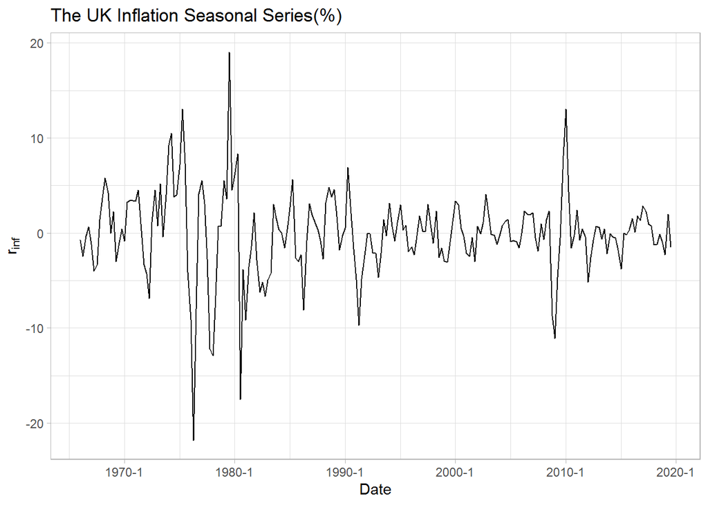

```r
#Plotting actual series of InfQ_diff4 variable.
ggplot(na.omit(data))+
  geom_line(aes(x = Date, y = InfQ_diff4))+
  labs(title = "The UK Inflation Seasonal Series(%)",
       y = expression('r'[inf]))+
  theme_light()
```

ADF test confirms stationarity.

```r
#Testing stationarity of InfQ_diff4 variable.
#H0: non-stationary;
#H1: stationary;
adf.test(inf4.xts)
```

```
##
##  Augmented Dickey-Fuller Test
##
## data:  inf4.xts
## Dickey-Fuller = -5.5327, Lag order = 5, p-value = 0.01
## alternative hypothesis: stationary
```

Parameters AR1 and SMA1 should be considered for the model, since at this point we observe high correlations.

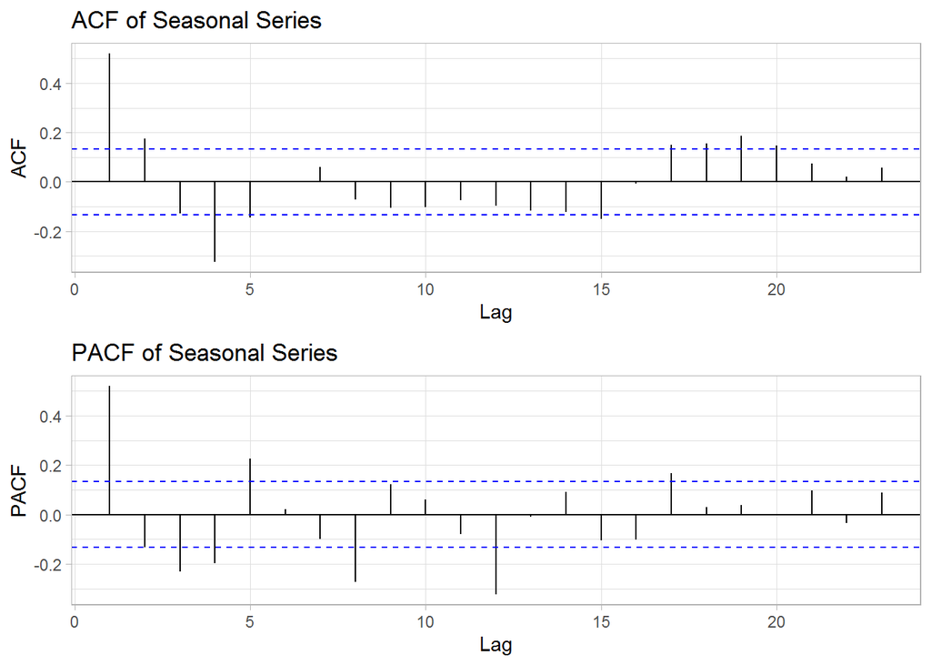

```r
#Plotting Acf and Pacf of seasonal series.
plot3 <- ggAcf(inf4.xts)+
          theme_light()+
          labs(title = "ACF of Seasonal Series")
plot4 <- ggPacf(inf4.xts)+
          theme_light()+
          labs(title = "PACF of Seasonal Series")

grid.arrange(plot3,
             plot4,
             nrow = 2)
```

```r
#Ljung-Box for detecting autocorrelations in seasonal series.
#H0: all correlations are zero;
#H1: there exists at least one, which is significantly higher than zero;
Box.test(inf4.ts, lag = 30, type = "Ljung-Box")
```

```
##
##  Box-Ljung test
##
## data:  inf4.ts
## X-squared = 157.1, df = 30, p-value < 2.2e-16
```

The distribution of seasonal data in non-normal as we see.

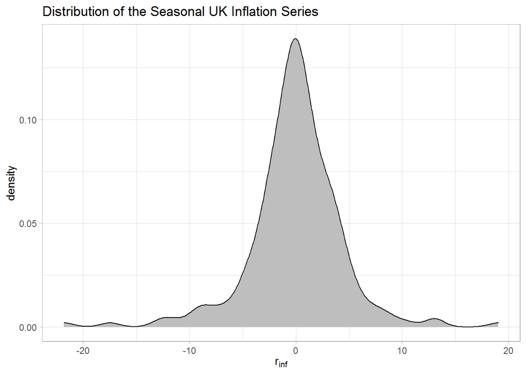

```r
#Plotting the distribution of seasonal series.
ggplot(na.omit(data))+
      geom_density(aes(InfQ_diff4), fill = "Grey")+
      labs(title = "Distribution of the Seasonal UK Inflation Series",
           x = expression('r'[inf]))+
  theme_light()
```

```r
#Testing normality of the distribution of seasonal series with Shapiro-Wilk test.
#H0: data normaly distributed;
#H1: data is not normaly distributied;
shapiro.test(inf4.ts)
```

```
##
##  Shapiro-Wilk normality test
##
## data:  inf4.ts
## W = 0.91783, p-value = 1.486e-09
```

The ARCH effect is still present, therefore GARCH model must be considered.

```r
#Testing ARCH effect in seasonal series.
#H0: there is no ARCH effect;
#H1: there is ARCH effect with a specified lag;
archtest(as.vector(inf4.ts), lag = 2)
```

```
##
##  Engle's LM ARCH Test
##
## data:  as.vector(inf4.ts)
## statistic = 12.169, lag = 2, p-value = 0.002277
## alternative hypothesis: ARCH effects of order 2 are present
```

```r
archtest(as.vector(inf4.ts), lag = 5)
```

```
##
##  Engle's LM ARCH Test
##
## data:  as.vector(inf4.ts)
## statistic = 37.137, lag = 5, p-value = 5.622e-07
## alternative hypothesis: ARCH effects of order 5 are present
```

```r
archtest(as.vector(inf4.ts), lag = 10)
```

```
##
##  Engle's LM ARCH Test
##
## data:  as.vector(inf4.ts)
## statistic = 53.008, lag = 10, p-value = 7.42e-08
## alternative hypothesis: ARCH effects of order 10 are present
```

# 3 Building ARFIMA with the ‘rugarch’ package

The rugarch package allows autoselection of the best specification according to the chosen criterion. All the parameters are statistically significant, d parameter is absent. The best specification is ARFIMA(4,0,3).

```r
#Autosearching for the best ARFIMA specification.
arfima <- autoarfima(data = inf.xts,
           ar.max = 4,
           ma.max = 4,
           criterion = "BIC",
           method = "partial",
           arfima = TRUE)
show(arfima)
```

```
## $fit
##
## *----------------------------------*
## *          ARFIMA Model Fit        *
## *----------------------------------*
## Mean Model   : ARFIMA(4,0,3)
## Distribution : norm
##
## Optimal Parameters
## ------------------------------------
##        Estimate  Std. Error  t value Pr(>|t|)
## mu      4.34175    0.481400   9.0190 0.000000
## ar1    -0.11513    0.046708  -2.4649 0.013706
## ar2    -0.15002    0.037311  -4.0209 0.000058
## ar3    -0.15202    0.047379  -3.2086 0.001334
## ar4     0.81101    0.037325  21.7284 0.000000
## ma1     0.77886    0.070985  10.9721 0.000000
## ma2     0.88100    0.056119  15.6986 0.000000
## ma3     0.76177    0.072892  10.4507 0.000000
## sigma   3.14141    0.148902  21.0971 0.000000
##
## Robust Standard Errors:
##        Estimate  Std. Error  t value Pr(>|t|)
## mu      4.34175    0.484178   8.9673 0.000000
## ar1    -0.11513    0.078899  -1.4592 0.144509
## ar2    -0.15002    0.067540  -2.2213 0.026332
## ar3    -0.15202    0.078520  -1.9360 0.052862
## ar4     0.81101    0.048218  16.8195 0.000000
## ma1     0.77886    0.161274   4.8294 0.000001
## ma2     0.88100    0.072935  12.0793 0.000000
## ma3     0.76177    0.187659   4.0593 0.000049
## sigma   3.14141    0.466684   6.7313 0.000000
##
## LogLikelihood : -561.4305
##
## Information Criteria
## ------------------------------------
##
## Akaike       5.2094
## Bayes        5.3487
```

[output cut: 135 more lines]

```
## 85  0  2    0      0   6.035885         1
## 86  3  3    0      0   6.041181         1
## 87  0  1    1      0   6.053643         1
## 88  0  3    0      0   6.060093         1
## 89  0  0    1      0   6.268618         1
## 90  0  1    0      0   6.525151         1
## 91  4  4    0      0 108.803752         1
## 92  4  4    1      0 109.864595         1
## 93  3  2    0      1         NA         0
## 94  3  3    0      1         NA         0
## 95  4  3    0      1         NA         0
## 96  4  4    0      1         NA         0
## 97  3  2    1      1         NA         0
## 98  4  3    1      1         NA         0
## 99  4  4    1      1         NA         0
```

As we can see the fit is good.

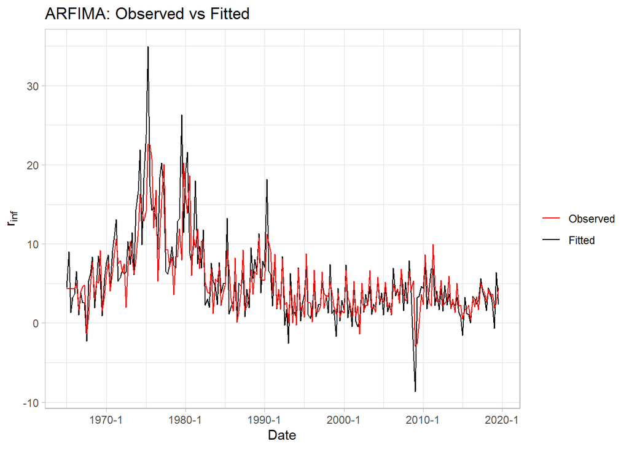

```r
#Plotting observed vs fitted.
ggplot(data.frame(Date = data$Date,
                  Observed = data$InfQ,
                  Fitted = fitted(arfima$fit))) +
  geom_line(aes(x = Date, y = Observed, colour = "Observed")) +
  geom_line(aes(x = Date, y = Fitted, colour = "Fitted")) +
  labs(y = expression('r'[inf]),
       title = "ARFIMA: Observed vs Fitted")+
  scale_color_manual(name = "",
                     labels = c("Observed", "Fitted"),
                     values = c("Observed" = "black",
                                "Fitted" = "red")) +
  theme_light()
```

The residuals are not normally distributed.

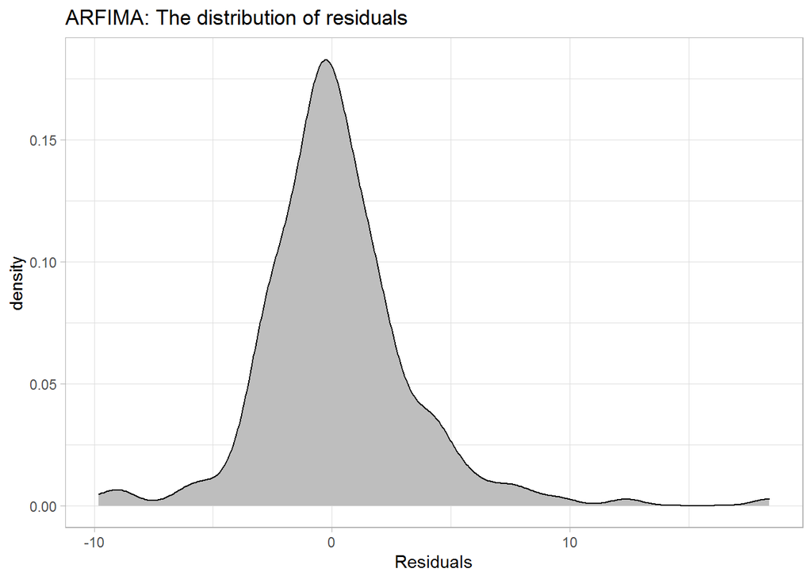

```r
#Plotting distribution of residuals.
ggplot(data.frame(Residuals = as.vector(residuals(arfima$fit)))) +
  geom_density(aes(Residuals), fill = "Grey") +
  labs(title = "ARFIMA: The distribution of residuals") +
  theme_light()
```

```r
#Testing normality of the distribution of ARFIMA residuals with Shapiro-Wilk test.
#H0: data normaly distributed;
#H1: data is not normaly distributied;
shapiro.test(as.vector(residuals(arfima$fit)))
```

```
##
##  Shapiro-Wilk normality test
##
## data:  as.vector(residuals(arfima$fit))
## W = 0.91191, p-value = 4.212e-10
```

The correlations are present, the model violates fundametal assumtions.

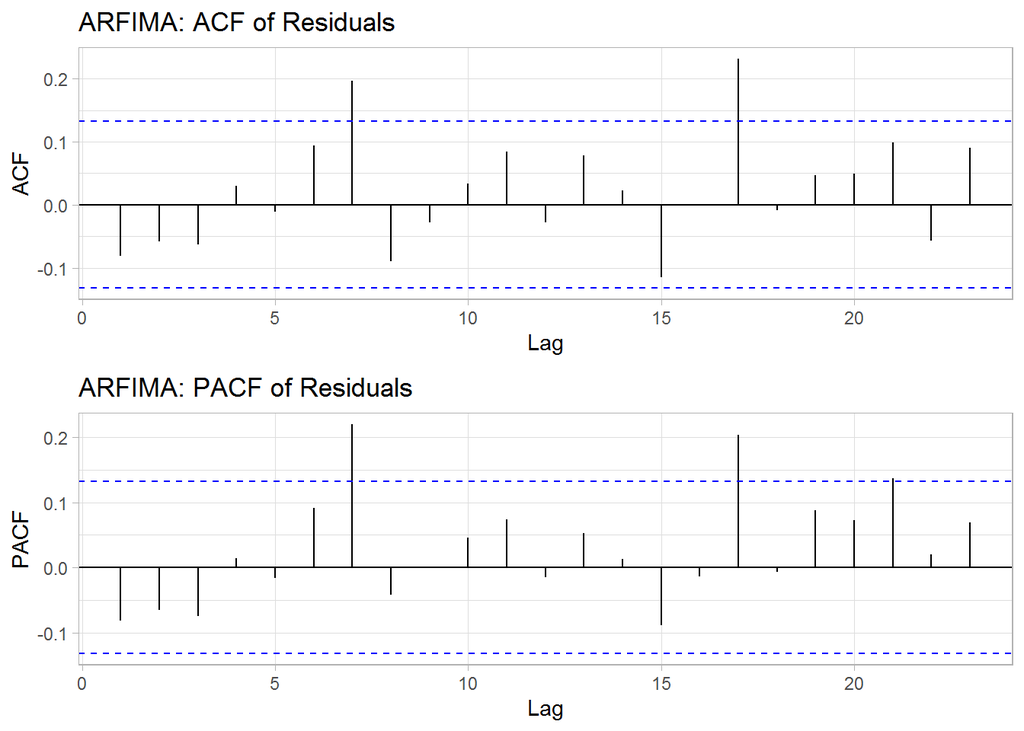

```r
#Plotting Acf and Pacf of ARFIMA residuals.
plot5 <- ggAcf(as.vector(residuals(arfima$fit)))+
          theme_light()+
          labs(title = "ARFIMA: ACF of Residuals")
plot6 <- ggPacf(as.vector(residuals(arfima$fit)))+
          theme_light()+
          labs(title = "ARFIMA: PACF of Residuals")

grid.arrange(plot5,
             plot6,
             nrow = 2)
```

```r
#Ljung-Box for detecting autocorrelations in ARFIMA residuals.
#H0: all correlations are zero;
#H1: there exists at least one, which is significantly higher than zero;
Box.test(as.vector(residuals(arfima$fit)), lag = 30, type = "Ljung-Box")
```

```
##
##  Box-Ljung test
##
## data:  as.vector(residuals(arfima$fit))
## X-squared = 49.193, df = 30, p-value = 0.01502
```

The ACF plot of squared series, for future GARCH analysis.

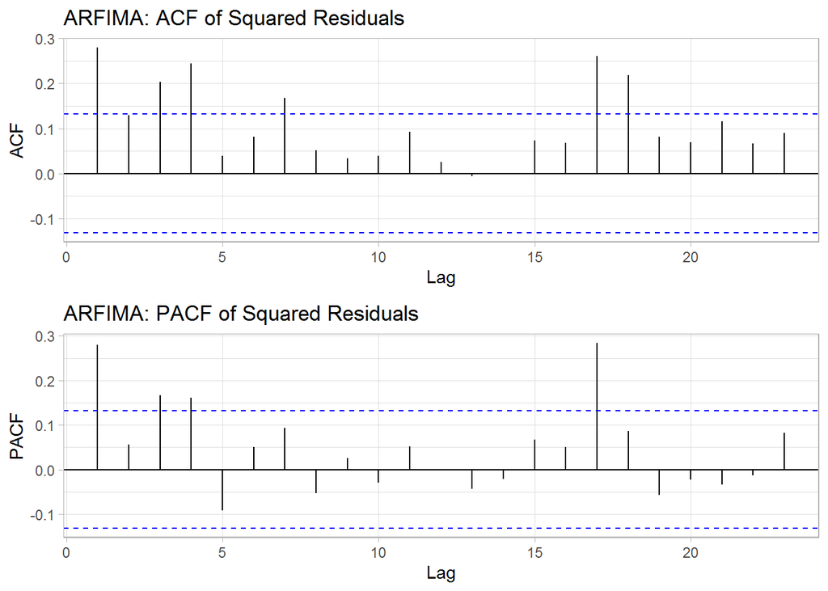

```r
#Plotting Acf and Pacf of ARFIMA squared residuals.
plot7 <- ggAcf(as.vector(residuals(arfima$fit))^2)+
          theme_light()+
          labs(title = "ARFIMA: ACF of Squared Residuals")
plot8 <- ggPacf(as.vector(residuals(arfima$fit))^2)+
         theme_light()+
        labs(title = "ARFIMA: PACF of Squared Residuals")

grid.arrange(plot7,
             plot8,
             nrow = 2)
```

```r
#Ljung-Box for detecting autocorrelations in squared residuals.
#H0: all correlations are zero;
#H1: there exists at least one, which is significantly higher than zero;
Box.test(as.vector(residuals(arfima$fit))^2, lag = 30, type = "Ljung-Box")
```

```
##
##  Box-Ljung test
##
## data:  as.vector(residuals(arfima$fit))^2
## X-squared = 97.908, df = 30, p-value = 3.962e-09
```

The forecasted values diviate from the observed ones.

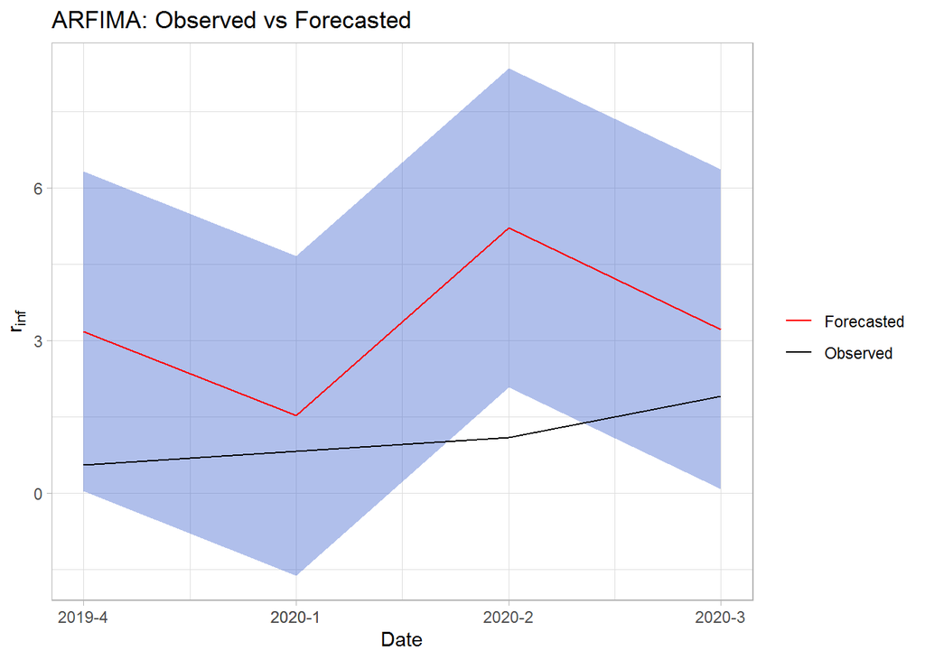

```r
#Calculating 4 forecasts.
arfima.forecast <- arfimaforecast(arfima$fit,
                                  inf.xts,
                                  n.ahead = 4)

#Plotting forecasted vs observed.
ggplot(data.frame(Date = last4$Date,
                  Observed = last4$InfQ,
                  Forecasted = as.vector(fitted(arfima.forecast)))) +
      geom_ribbon(aes(x = Date,
                      y = Forecasted,
                      ymin = Forecasted - 3.14141 ,
                      ymax = Forecasted + 3.14141),
              fill = "royalblue3",
              alpha=0.4) +
  geom_line(aes(x = Date, y = Forecasted, colour = "Forecasted")) +
  geom_line(aes(x = Date, y = Observed, colour = "Observed")) +
  labs(y = expression('r'[inf]),
       title = "ARFIMA: Observed vs Forecasted")+
  scale_color_manual(name = "",
                     labels = c("Forecasted", "Observed"),
                     values = c("Observed" = "black",
                                "Forecasted" = "red")) +
  theme_light()
```

# 4 Building SARIMA with the ‘forecast’ package

The ‘forecast’ package also anables auto-selection, but unfortunately the report is not informative enough. The best specification is ARIMA(1,1,1)(1,0,0)[4].

```r
#Autosearching for the best SARIMA specification.
sarima <- auto.arima(inf.ts,
                    trace = TRUE)
```

```
##
##  Fitting models using approximations to speed things up...
##
##  ARIMA(2,1,2)(1,0,1)[4] with drift         : Inf
##  ARIMA(0,1,0)           with drift         : 1299.976
##  ARIMA(1,1,0)(1,0,0)[4] with drift         : 1202.377
##  ARIMA(0,1,1)(0,0,1)[4] with drift         : 1203.559
##  ARIMA(0,1,0)                              : 1297.939
##  ARIMA(1,1,0)           with drift         : 1248.07
##  ARIMA(1,1,0)(2,0,0)[4] with drift         : 1192.473
##  ARIMA(1,1,0)(2,0,1)[4] with drift         : Inf
##  ARIMA(1,1,0)(1,0,1)[4] with drift         : Inf
##  ARIMA(0,1,0)(2,0,0)[4] with drift         : 1205.48
##  ARIMA(2,1,0)(2,0,0)[4] with drift         : 1193.862
##  ARIMA(1,1,1)(2,0,0)[4] with drift         : 1170.343
##  ARIMA(1,1,1)(1,0,0)[4] with drift         : 1163.141
##  ARIMA(1,1,1)           with drift         : 1226.867
##  ARIMA(1,1,1)(1,0,1)[4] with drift         : Inf
##  ARIMA(1,1,1)(0,0,1)[4] with drift         : 1195.329
##  ARIMA(1,1,1)(2,0,1)[4] with drift         : Inf
##  ARIMA(0,1,1)(1,0,0)[4] with drift         : 1194.728
##  ARIMA(2,1,1)(1,0,0)[4] with drift         : 1170.547
##  ARIMA(1,1,2)(1,0,0)[4] with drift         : 1165.243
##  ARIMA(0,1,0)(1,0,0)[4] with drift         : 1212.543
##  ARIMA(0,1,2)(1,0,0)[4] with drift         : 1177.036
##  ARIMA(2,1,0)(1,0,0)[4] with drift         : 1204.732
##  ARIMA(2,1,2)(1,0,0)[4] with drift         : Inf
##  ARIMA(1,1,1)(1,0,0)[4]                    : 1161.518
##  ARIMA(1,1,1)                              : 1224.832
##  ARIMA(1,1,1)(2,0,0)[4]                    : 1168.248
##  ARIMA(1,1,1)(1,0,1)[4]                    : Inf
##  ARIMA(1,1,1)(0,0,1)[4]                    : 1193.481
##  ARIMA(1,1,1)(2,0,1)[4]                    : Inf
##  ARIMA(0,1,1)(1,0,0)[4]                    : 1192.652
##  ARIMA(1,1,0)(1,0,0)[4]                    : 1200.302
##  ARIMA(2,1,1)(1,0,0)[4]                    : 1168.439
##  ARIMA(1,1,2)(1,0,0)[4]                    : 1163.612
##  ARIMA(0,1,0)(1,0,0)[4]                    : 1210.487
##  ARIMA(0,1,2)(1,0,0)[4]                    : 1174.961
##  ARIMA(2,1,0)(1,0,0)[4]                    : 1202.637
##  ARIMA(2,1,2)(1,0,0)[4]                    : Inf
##
##  Now re-fitting the best model(s) without approximations...
##
##  ARIMA(1,1,1)(1,0,0)[4]                    : 1163.955
##
##  Best model: ARIMA(1,1,1)(1,0,0)[4]
```

```r
sarima
```

```
## Series: inf.ts
## ARIMA(1,1,1)(1,0,0)[4]
##
## Coefficients:
##          ar1      ma1    sar1
##       0.5163  -0.9761  0.5826
## s.e.  0.0636   0.0201  0.0599
##
## sigma^2 estimated as 11.79:  log likelihood=-577.88
## AIC=1163.77   AICc=1163.95   BIC=1177.31
```

The fit looks ok.

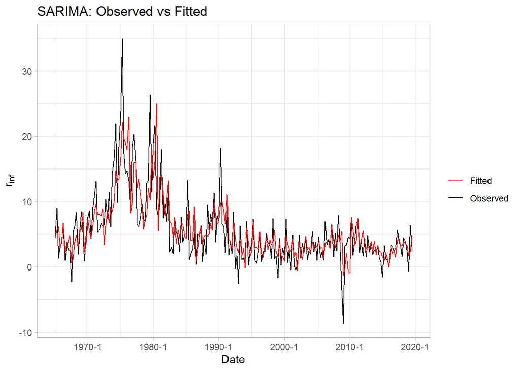

```r
#Plotting observed vs fitted.
ggplot(data.frame(Date = data$Date,
                  Observed = data$InfQ,
                  Fitted = sarima$fitted)) +
  geom_line(aes(x = Date, y = Observed, col = "Observed")) +
  geom_line(aes(x = Date, y = Fitted, col = "Fitted")) +
  labs(y = expression('r'[inf]),
       title = "SARIMA: Observed vs Fitted")+
  scale_color_manual(name = "",
                     values = c("Observed" = "black",
                                "Fitted" = "red")) +
  theme_light()
```

The picture the same as in the previous case.

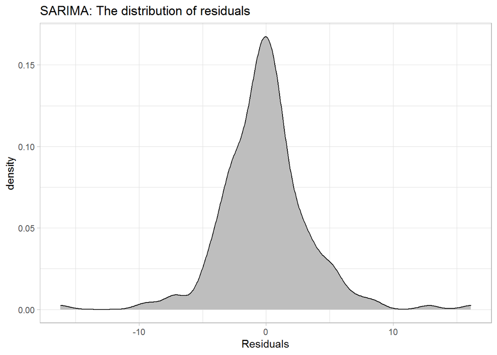

```r
#Plotting distribution of residuals.
ggplot(data.frame(Residuals = as.vector(sarima$residuals))) +
  geom_density(aes(Residuals), fill = "Grey") +
  labs(title = "SARIMA: The distribution of residuals") +
  theme_light()
```

```r
#Testing normality of the distribution of SARIMA residuals with Shapiro-Wilk test.
#H0: data normaly distributed;
#H1: data is not normaly distributied;
shapiro.test(as.vector(sarima$residuals))
```

```
##
##  Shapiro-Wilk normality test
##
## data:  as.vector(sarima$residuals)
## W = 0.93572, p-value = 3.179e-08
```

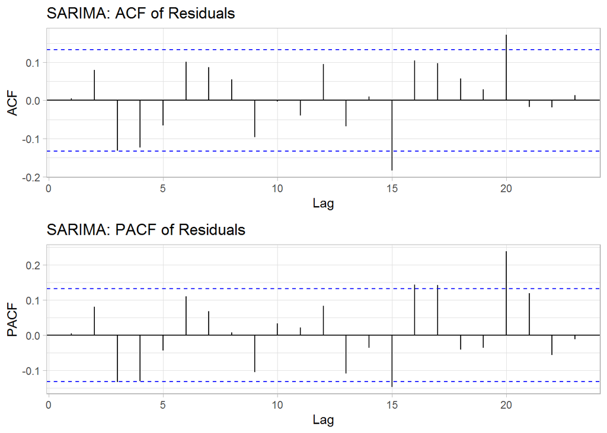

```r
#Plotting Acf and Pacf of SARIMA residuals.
plot9 <- ggAcf(as.vector(sarima$residuals))+
          theme_light()+
          labs(title = "SARIMA: ACF of Residuals")
plot10 <- ggPacf(as.vector(sarima$residuals))+
          theme_light()+
          labs(title = "SARIMA: PACF of Residuals")

grid.arrange(plot9,
             plot10,
             nrow = 2)
```

```r
#Ljung-Box for detecting autocorrelations in SARIMA residuals.
#H0: all correlations are zero;
#H1: there exists at least one, which is significantly higher than zero;
Box.test(as.vector(sarima$residuals), lag = 30, type = "Ljung-Box")
```

```
##
##  Box-Ljung test
##
## data:  as.vector(sarima$residuals)
## X-squared = 57.968, df = 30, p-value = 0.001611
```

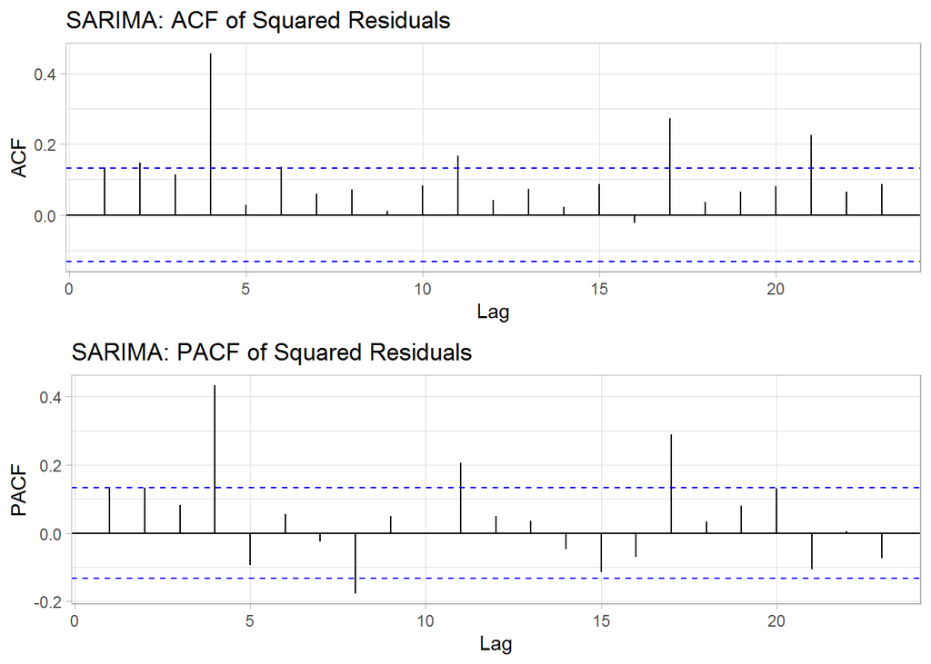

```r
#Plotting Acf and Pacf of SARIMA squared residuals.
plot11 <- ggAcf(as.vector(sarima$residuals)^2)+
          theme_light()+
          labs(title = "SARIMA: ACF of Squared Residuals")
plot12 <- ggPacf(as.vector(sarima$residuals)^2)+
         theme_light()+
        labs(title = "SARIMA: PACF of Squared Residuals")

grid.arrange(plot11,
             plot12,
             nrow = 2)
```

```r
#Ljung-Box for detecting autocorrelations in SARIMA residuals.
#H0: all correlations are zero;
#H1: there exists at least one, which is significantly higher than zero;
Box.test(as.vector(sarima$residuals)^2, lag = 30, type = "Ljung-Box")
```

```
##
##  Box-Ljung test
##
## data:  as.vector(sarima$residuals)^2
## X-squared = 115.65, df = 30, p-value = 5.42e-12
```

The forecast is more or less correct in the two periods 2020/Q1 and 2020/Q3.

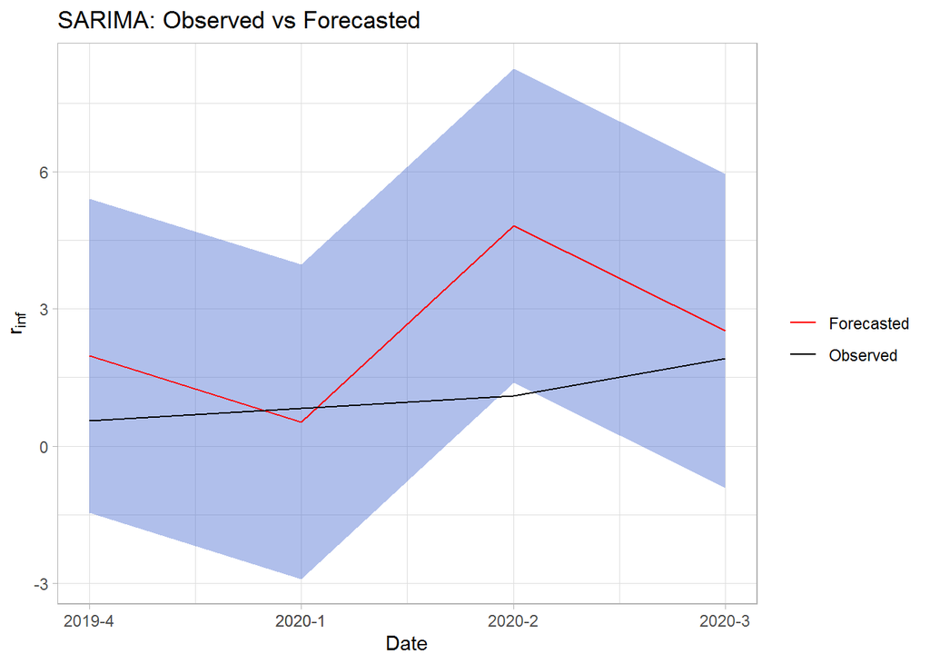

```r
#Calculating 4 forecasts.
sarima.forecast <- forecast(sarima, h = 4)

#Plotting forecasted vs observed.
ggplot(data.frame(Date = last4$Date,
                  Observed = last4$InfQ,
                  Forecasted = as.vector(sarima.forecast$mean))) +
      geom_ribbon(aes(x = Date,
                      y = Forecasted,
                      ymin = as.vector(sarima.forecast$mean - 11.79^0.5),
                      ymax = as.vector(sarima.forecast$mean + 11.79^0.5)),
              fill = "royalblue3",
              alpha=0.4) +
  geom_line(aes(x = Date, y = Forecasted, colour = "Forecasted")) +
  geom_line(aes(x = Date, y = Observed, colour = "Observed")) +
  labs(y = expression('r'[inf]),
       title = "SARIMA: Observed vs Forecasted")+
  scale_color_manual(name = "",
                     labels = c("Forecasted", "Observed"),
                     values = c("Observed" = "black",
                                "Forecasted" = "red")) +
  theme_light()
```

# 5 Building SARFIMA with the ‘arfima’ package

```r
#Building SARFIMA
sarfima <- arfima::arfima(inf.ts,
                          order = c(4,0,1),
                          seasonal = list(order = c(2, 0, 0),
                          period = 4),
                          fixed = list(frac = c(0),
                                       seasonal = list(phi = c(0, NA),
                                                       frac = c(NA))))
```

```
## Note: only one starting point.  Only one mode can be found -- this is now the default behavior.
## Beginning the fits with 1 starting values.
```

```r
summary(sarfima)
```

```
##
## Call:
##
## arfima::arfima(z = inf.ts, order = c(4, 0, 1), fixed = list(frac = c(0), seasonal = list(phi = c(0,
##     NA), frac = c(NA))), seasonal = list(order = c(2, 0, 0), period = 4))
##
##
## Mode 1 Coefficients:
##               Estimate Std. Error Th. Std. Err.  z-value   Pr(>|z|)
## phi(1)       1.3608402  0.1930544     0.3720215  7.04900 1.8021e-12 ***
## phi(2)      -0.3505222  0.1571623     0.3322650 -2.23032   0.025726 *
## phi(3)      -0.2320677  0.1139298     0.1219836 -2.03694   0.041656 *
## phi(4)       0.1652589  0.0714073     0.0835284  2.31431   0.020651 *
## theta(1)     0.7743766  0.1877765     0.2230695  4.12393 3.7247e-05 ***
## phi.4(1)     0.0000000         NA     0.1416333       NA         NA
## phi.4(2)    -0.1280551  0.0745989     0.0831805 -1.71658   0.086056 .
## d.f          0.0000000         NA     0.3902563       NA         NA
## d.f.4        0.3678061  0.0416893     0.1134019  8.82255 < 2.22e-16 ***
## Fitted mean  5.0689134  3.9648455            NA  1.27846   0.201086
## ---
## Signif. codes:  0 '***' 0.001 '**' 0.01 '*' 0.05 '.' 0.1 ' ' 1
## sigma^2 estimated as 9.94952; Log-likelihood = -249.586; AIC = 521.173; BIC = 558.453
##
## Numerical Correlations of Coefficients:
##             phi(1) phi(2) phi(3) phi(4) theta(1) phi.4(1) phi.4(2) d.f   d.f.4
## phi(1)       1.00  -0.85   0.08  -0.20   0.94      NaN    -0.09      NaN  0.16
## phi(2)      -0.85   1.00  -0.48   0.31  -0.69      NaN     0.08      NaN -0.21
## phi(3)       0.08  -0.48   1.00  -0.79   0.00      NaN     0.16      NaN -0.01
## phi(4)      -0.20   0.31  -0.79   1.00  -0.22      NaN    -0.28      NaN  0.07
## theta(1)     0.94  -0.69   0.00  -0.22   1.00      NaN    -0.06      NaN  0.10
## phi.4(1)      NaN    NaN    NaN    NaN    NaN     0.00      NaN     0.00   NaN
## phi.4(2)    -0.09   0.08   0.16  -0.28  -0.06      NaN     1.00      NaN -0.30
## d.f           NaN    NaN    NaN    NaN    NaN     0.00      NaN     0.00   NaN
## d.f.4        0.16  -0.21  -0.01   0.07   0.10      NaN    -0.30      NaN  1.00
## Fitted mean -0.04   0.03   0.00   0.00  -0.04      NaN     0.01      NaN -0.01
##             Fitted mean
## phi(1)      -0.04
## phi(2)       0.03
## phi(3)       0.00
## phi(4)       0.00
```

[output cut: 15 more lines]

```
## phi.4(2) -0.07   0.12  -0.14  -0.02   0.24     0.40     1.00    -0.20  0.51
## d.f       0.82  -0.87   0.16   0.38  -0.38     0.11    -0.20     1.00 -0.09
## d.f.4     0.07   0.02  -0.34   0.34   0.28     0.80     0.51    -0.09  1.00
##
## Expected Fisher Information Matrix of Coefficients:
##          phi(1) phi(2) phi(3) phi(4) theta(1) phi.4(1) phi.4(2) d.f   d.f.4
## phi(1)    9.40   8.80   7.95   7.04  -3.45     0.84     0.48    -2.62 -1.43
## phi(2)    8.80   9.50   9.14   8.38  -2.36     1.00     0.55    -1.59 -1.68
## phi(3)    7.95   9.14  10.06   9.78  -1.61     0.89     0.68    -1.17 -1.69
## phi(4)    7.04   8.38   9.78  10.76  -1.08     0.56     0.88    -0.95 -1.75
## theta(1) -3.45  -2.36  -1.61  -1.08   2.02    -0.31    -0.09     1.57  0.34
## phi.4(1)  0.84   1.00   0.89   0.56  -0.31     0.97    -0.02    -0.14 -0.89
## phi.4(2)  0.48   0.55   0.68   0.88  -0.09    -0.02     1.00    -0.06 -0.43
## d.f      -2.62  -1.59  -1.17  -0.95   1.57    -0.14    -0.06     1.39  0.24
## d.f.4    -1.43  -1.68  -1.69  -1.75   0.34    -0.89    -0.43     0.24  1.53
```

```r
#Extracting residuals and fitted values.
sarfima.res <- ts(as.vector(unlist(residuals(sarfima))), start = c(1965), frequency = 4)
sarfima.fit <- as.vector(unlist(fitted(sarfima)))
sarfima.forecast <- predict(sarfima, n.ahead = 4)
```

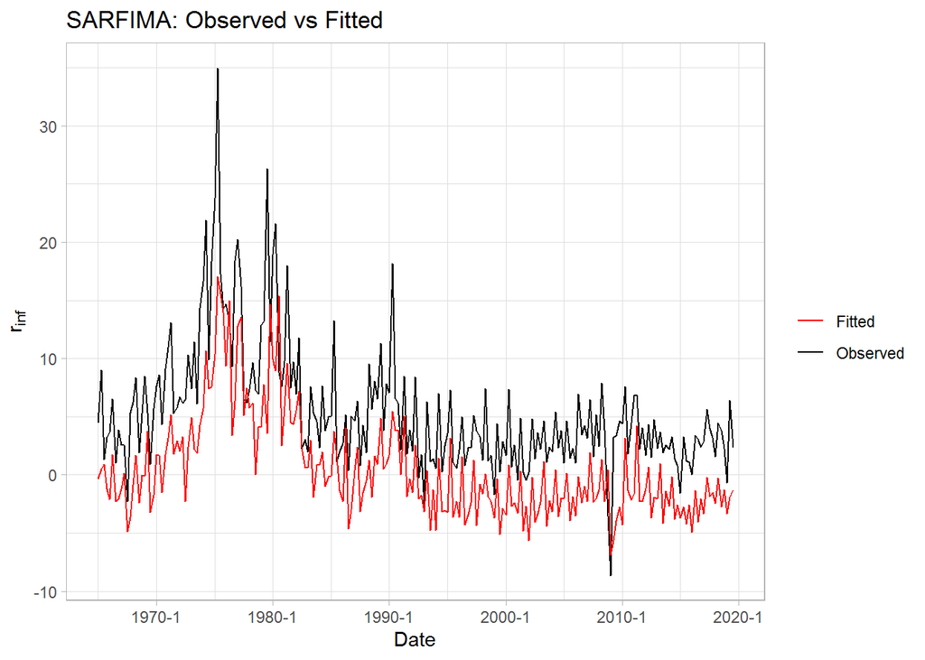

```r
start <- length(data$Date)-length(sarfima.fit)+1

ggplot(data.frame(Date = data$Date[start:length(data$Date)],
                  Observed = data$InfQ[start:length(data$Date)],
                  Fitted = sarfima.fit))+
  geom_line(aes(x = Date, y = Observed, colour = "Observed")) +
  geom_line(aes(x = Date, y = Fitted, colour = "Fitted")) +
  labs(y = expression('r'[inf]),
       title = "SARFIMA: Observed vs Fitted")+
  scale_color_manual(name = "",
                     values = c("Observed" = "black",
                                "Fitted" = "red")) +
  theme_light()
```

The distribution is still has non-normal shape.

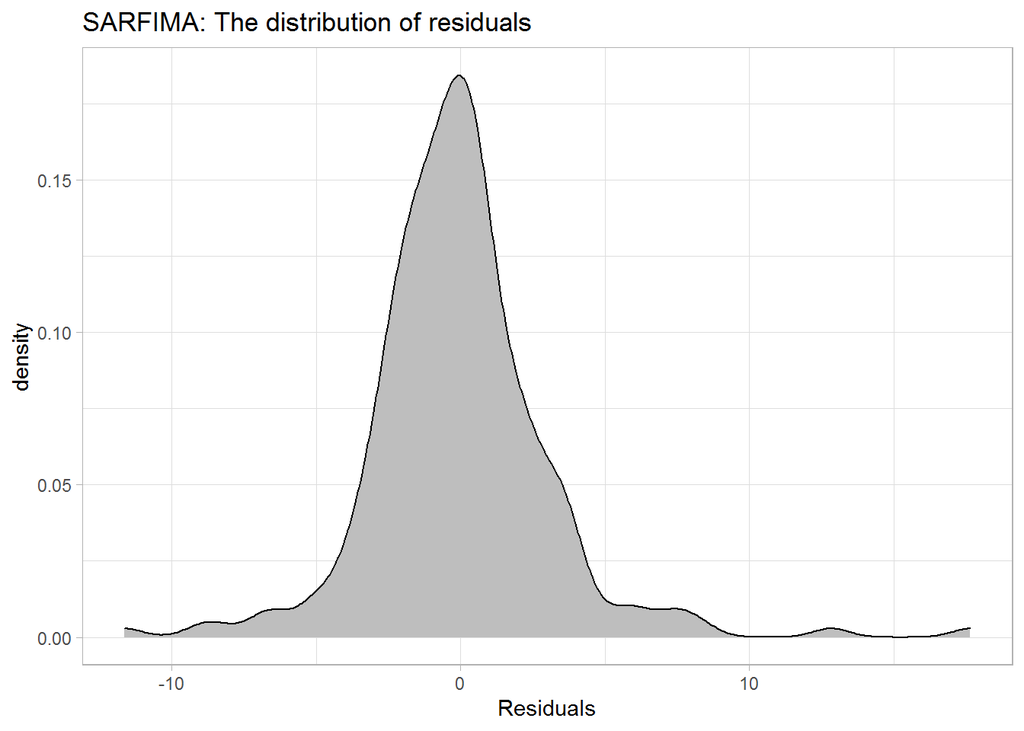

```r
#Plotting distribution of residuals.
ggplot(data.frame(Residuals = as.vector(sarfima.res))) +
  geom_density(aes(Residuals), fill = "Grey") +
  labs(title = "SARFIMA: The distribution of residuals") +
  theme_light()
```

```r
#Testing normality of the distribution of SARFIMA residuals with Shapiro-Wilk test.
#H0: data normaly distributed;
#H1: data is not normaly distributied;
shapiro.test(as.vector(sarfima.res))
```

```
##
##  Shapiro-Wilk normality test
##
## data:  as.vector(sarfima.res)
## W = 0.91001, p-value = 3.088e-10
```

Hovewer, the residuals are not correlated anymore.

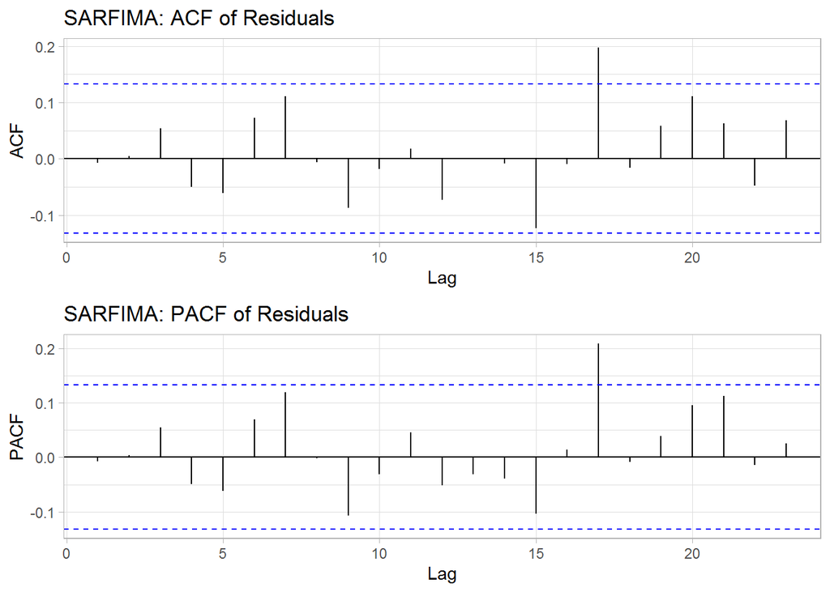

```r
#Plotting Acf and Pacf of SARFIMA residuals.
plot13 <- ggAcf(as.vector(sarfima.res))+
          theme_light()+
          labs(title = "SARFIMA: ACF of Residuals")
plot14 <- ggPacf(as.vector(sarfima.res))+
          theme_light()+
          labs(title = "SARFIMA: PACF of Residuals")

grid.arrange(plot13,
             plot14,
             nrow = 2)
```

```r
#Ljung-Box for detecting autocorrelations in SARFIMA residuals.
#H0: all correlations are zero;
#H1: there exists at least one, which is significantly higher than zero;
Box.test(as.vector(sarfima.res), lag = 30, type = "Ljung-Box")
```

```
##
##  Box-Ljung test
##
## data:  as.vector(sarfima.res)
## X-squared = 33.055, df = 30, p-value = 0.3201
```

Although, the squared residuals show some dependence, so the GARCH model should be considered.

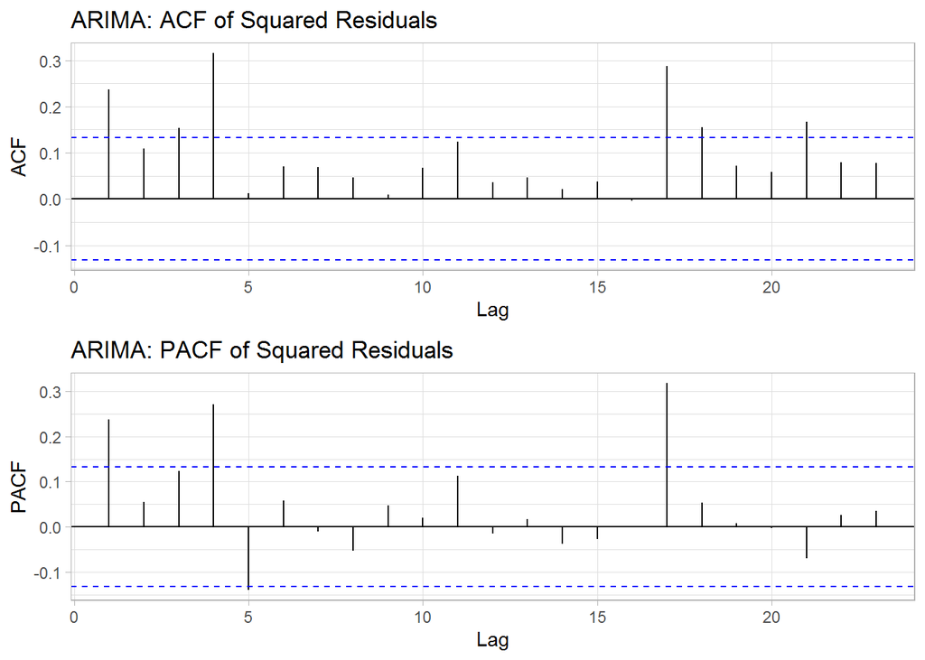

```r
#Plotting Acf and Pacf of SARFIMA squared residuals.
plot11 <- ggAcf(as.vector(sarfima.res)^2)+
          theme_light()+
          labs(title = "ARIMA: ACF of Squared Residuals")
plot12 <- ggPacf(as.vector(sarfima.res)^2)+
         theme_light()+
        labs(title = "ARIMA: PACF of Squared Residuals")

grid.arrange(plot11,
             plot12,
             nrow = 2)
```

```r
#Ljung-Box for detecting autocorrelations in SARFIMA residuals.
#H0: all correlations are zero;
#H1: there exists at least one, which is significantly higher than zero;
Box.test(as.vector(sarfima.res)^2, lag = 30, type = "Ljung-Box")
```

```
##
##  Box-Ljung test
##
## data:  as.vector(sarfima.res)^2
## X-squared = 90.328, df = 30, p-value = 5.856e-08
```

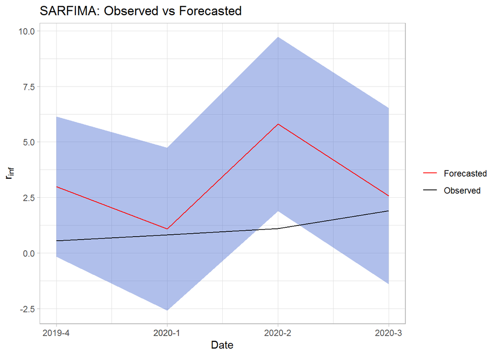

```r
#Plotting forecasted vs observed.
ggplot(data.frame(Date = last4$Date,
                  Observed = last4$InfQ,
                  Forecasted = sarfima.forecast[[1]]$Forecast)) +
      geom_ribbon(aes(x = Date,
                      y = Forecasted,
                      ymin = sarfima.forecast[[1]]$Forecast - sarfima.forecast[[1]]$SDForecasts,
                      ymax = sarfima.forecast[[1]]$Forecast + sarfima.forecast[[1]]$SDForecasts),
              fill = "royalblue3",
              alpha=0.4) +
  geom_line(aes(x = Date, y = Forecasted, colour = "Forecasted")) +
  geom_line(aes(x = Date, y = Observed, colour = "Observed")) +
  labs(y = expression('r'[inf]),
       title = "SARFIMA: Observed vs Forecasted")+
  scale_color_manual(name = "",
                     labels = c("Forecasted", "Observed"),
                     values = c("Observed" = "black",
                                "Forecasted" = "red")) +
  theme_light()
```